# IODS final assignment

Ilari Hotti : ilari.hotti@helsinki.fi

8.3.2017

## Introduction

For this assignment I manipulated survey data about young Slovakians and created a variable about depression from their opinions and life views that indicated negative and anxious thought patterns. I investigated the young people’s music and movie preferences and other variables to find connections to the depression indicator. Linear modelling is used to quantify the connections.

I’m interested in finding any kind of correlations between depression and music and movie preferences or hobbies. My goal is also to visualize the variables in a way that helps make the connections clear.

## Presenting the data

#### Basic info

I chose a survey dataset from [kaggle](https://www.kaggle.com/miroslavsabo/young-people-survey) for my final assignment.

The data is from a Slovakian survey about music and movie preferences, hobbies & interests, phobias, health habits, personality traits, views on life , opinions, spending habits and finally demographics. Participants were Slovakians aged 15 to 30. Most of the variables had integer values from 1 to 5 representing how much the participant agrees with the statement in question.

#### Data wrangling

The dataset origanally contained 1010 observations and 150 variables. I created 4 new variables: `BMI` (calculated from weight and height), `Sports` (averaged passive and active sports interests) and `Depression` (averaged 10 questions that indicated depressed and anxious thinking: Self.criticism, Hypochondria, Loneliness, Changing.the.past, Life.struggles, Getting.up, Happiness, Energylevels, Personality_positivity and Socializing (last five had to be flipped around)). I also created a categorical variable for participants who scored higher or lower than 3.3 in my `Depression` index.

I chose to include all the variables about music and movie preferences, `Healthy_eating`, `Dancing`, `Age` and `Gender` in addition to the variables I created. So in the end there are 39 variables.

There were also missing values and removing them meant the dataset shrank a bit to 832 observations.

[Here](https://github.com/ilarjod/IODS-final/blob/master/data/create_young_minds.R) is a link to the data wrangling script.

#### Examining data structure

```r
library("tidyverse")
library("ggplot2")
library("dplyr")
library("GGally")
library("corrplot")
library("gridExtra")
library("gridBase")
ym <- read.table("data/young_minds.txt")
Palette <- c("#56B4E9", "firebrick1")
Palette2 <- c("#56B4E9", "gray27")
Palette3 <- c("#56B4E9", "orange")
Palette4 <- c("#56B4E9", "purple")
sexpalette = c("blue", "deeppink")
```

Let’s examine the data set.

```r
glimpse(ym)
```

```
## Observations: 832
## Variables: 39
## $ Age            <int> 20, 19, 20, 22, 20, 20, 20, 19, 19, 19, 17, 24,...
## $ Gender         <fctr> female, female, female, female, female, male, ...
## $ BMI            <dbl> 18.06617, 21.82995, 21.62965, 19.94321, 20.4152...
## $ Depression     <dbl> 1.7, 2.7, 3.1, 3.9, 2.9, 2.6, 2.2, 2.6, 2.7, 3....
## $ Depressed      <lgl> FALSE, FALSE, FALSE, TRUE, FALSE, FALSE, FALSE,...
## $ Sports         <dbl> 3.0, 1.0, 3.5, 1.0, 2.0, 4.5, 4.0, 4.5, 4.0, 3....
## $ Healthy_eating <int> 4, 3, 3, 3, 4, 2, 4, 2, 3, 3, 3, 3, 3, 1, 5, 3,...
## $ Dancing        <int> 3, 1, 5, 1, 1, 1, 3, 1, 5, 1, 1, 3, 3, 1, 1, 2,...
## $ Music          <int> 5, 4, 5, 5, 5, 5, 5, 5, 5, 5, 5, 5, 5, 5, 1, 5,...
## $ Slow_vs_Fast   <int> 3, 4, 5, 3, 3, 3, 5, 3, 3, 3, 3, 3, 3, 3, 3, 3,...
## $ Dance          <int> 2, 2, 2, 2, 4, 2, 5, 3, 2, 3, 1, 1, 5, 2, 2, 3,...
## $ Folk           <int> 1, 1, 2, 1, 3, 3, 3, 2, 5, 2, 1, 2, 3, 1, 2, 1,...
## $ Country        <int> 2, 1, 3, 1, 2, 2, 1, 1, 2, 1, 1, 1, 2, 1, 3, 1,...
```

[output cut: 26 more lines]

```r
summary(ym$Gender)
```

```
## female   male
##    497    335
```

```r
summary(ym$Depressed)
```

```
##    Mode   FALSE    TRUE    NA's
## logical     703     129       0
```

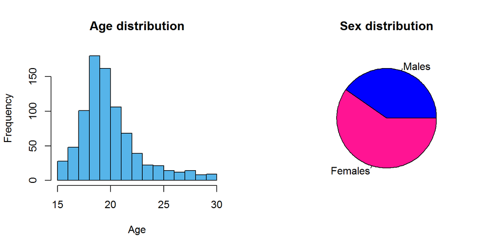

```r
m <- sum(ym$Gender == "male" )
f <- sum(ym$Gender == "female")
sexsums <- c(m,f)
lbls <- c("Males", "Females")

par(mfrow=c(1,2))
age <- hist(ym$Age, xlab ="Age", col = "#56B4E9", main="Age distribution")
sex <- pie(sexsums, labels = lbls, col = sexpalette,  main="Sex distribution")
```

There are 497 female and 335 male participants. 129 of them are depressed according to my variable and categorization. Most are around 20 years old. The variables are all very similar with integer values 1 to 5 except for the variables created by me.

#### Visualizing the variables

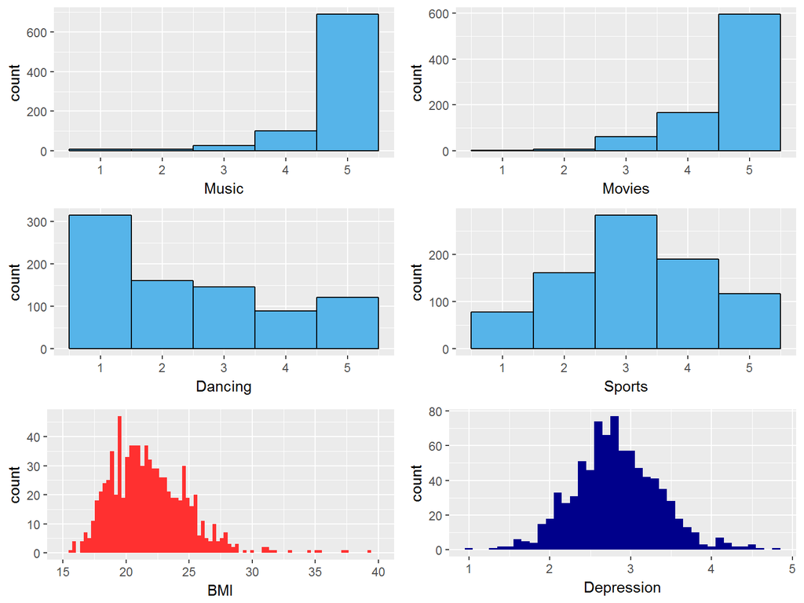

```r
Mu <- ggplot(ym, aes(x = Music)) + geom_histogram(binwidth = 1, color = "black", fill = "#56B4E9")
Mo <- ggplot(ym, aes(x = Movies)) + geom_histogram(binwidth = 1, color = "black", fill = "#56B4E9")
Da <- ggplot(ym, aes(x = Dancing)) + geom_histogram(binwidth = 1, color = "black", fill = "#56B4E9")
Sp <- ggplot(ym, aes(x = Sports)) + geom_histogram(binwidth = 1, color = "black", fill = "#56B4E9")
Bm <- ggplot(ym, aes(x = BMI)) + geom_histogram(binwidth = 0.3, fill = "firebrick1") + xlim(15, 40)
De <- ggplot(ym, aes(x = Depression)) + geom_histogram(binwidth = 0.1, fill = "darkblue")
grid.arrange(Mu, Mo, Da, Sp, Bm, De, ncol=2)
```

Everybody likes music and movies in general. `Depression` seems to have a bit of a bell curve shape.

## Correlations

So what kind of correlations can we find in the data? We can have a short look at the correlations between different music preferences and movie preferences.

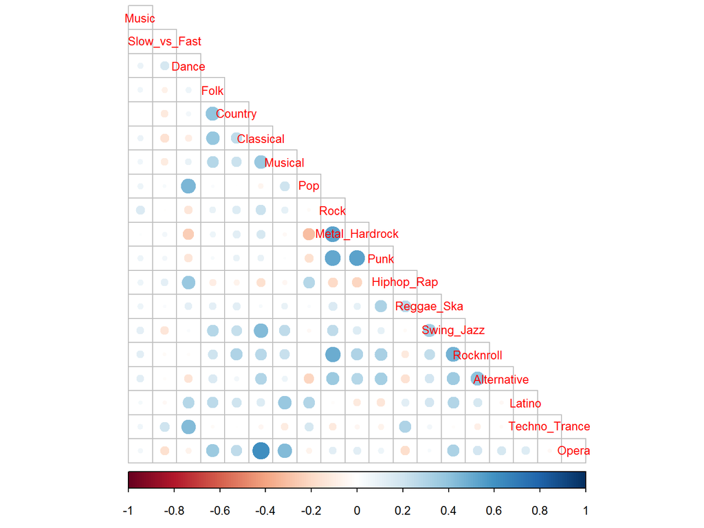

```r
music_matrix <- cor(ym[9:27]) %>% round(digits = 2)
movie_matrix <- cor(ym[28:39]) %>% round(digits = 2)

corrplot(music_matrix, method="circle", type="lower", cl.pos = "b", tl.pos = "d", tl.cex = 0.8)
```

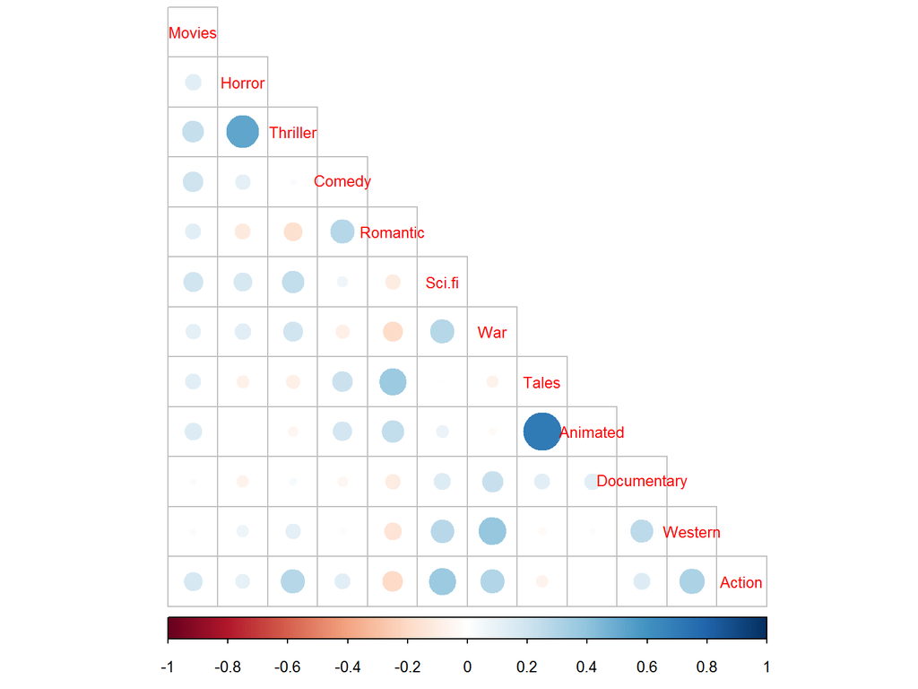

```r
corrplot(movie_matrix, method="circle", type="lower", cl.pos = "b", tl.pos = "d", tl.cex = 0.8)
```

The correlations make sense but are not very interesting. The goal is to find predictors for the `Depression`.

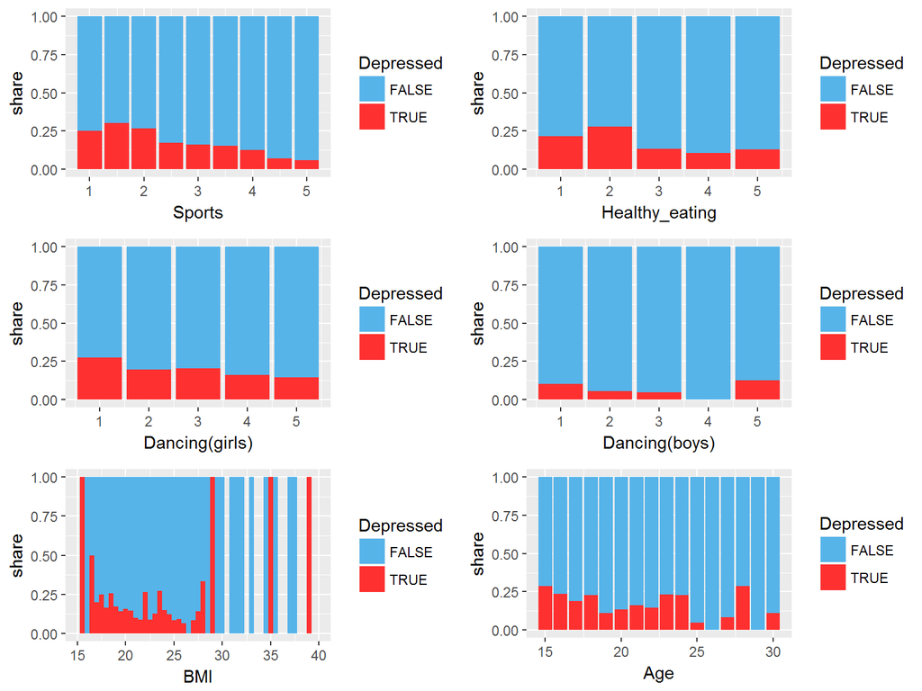

```r
spoD <- ggplot(ym, aes(x = Sports, fill = Depressed)) + geom_bar(position="fill") + scale_fill_manual(values=Palette) + ylab("share")
eatD <- ggplot(ym, aes(x = Healthy_eating, fill = Depressed)) + geom_bar(position="fill") + scale_fill_manual(values=Palette) + ylab("share")
danD <- ggplot(filter(ym, Gender == "female"), aes(x = Dancing, fill = Depressed)) + geom_bar(position="fill") + scale_fill_manual(values=Palette) +xlab("Dancing(girls)") + ylab("share")
danDb <- ggplot(filter(ym, Gender == "male"), aes(x = Dancing, fill = Depressed)) + geom_bar(position="fill") + scale_fill_manual(values=Palette) +xlab("Dancing(boys)") + ylab("share")
bmiD <- ggplot(ym, aes(x = BMI, fill = Depressed)) + geom_histogram(binwidth = 0.5 , position="fill") +  scale_fill_manual(values=Palette)+xlim(15,40)+ ylab("share")
ageD <- ggplot(ym, aes(x = Age, fill = Depressed)) + geom_bar(position="fill") + scale_fill_manual(values=Palette)+ ylab("share")
grid.arrange(spoD, eatD, danD, danDb, bmiD, ageD, ncol=2)
```

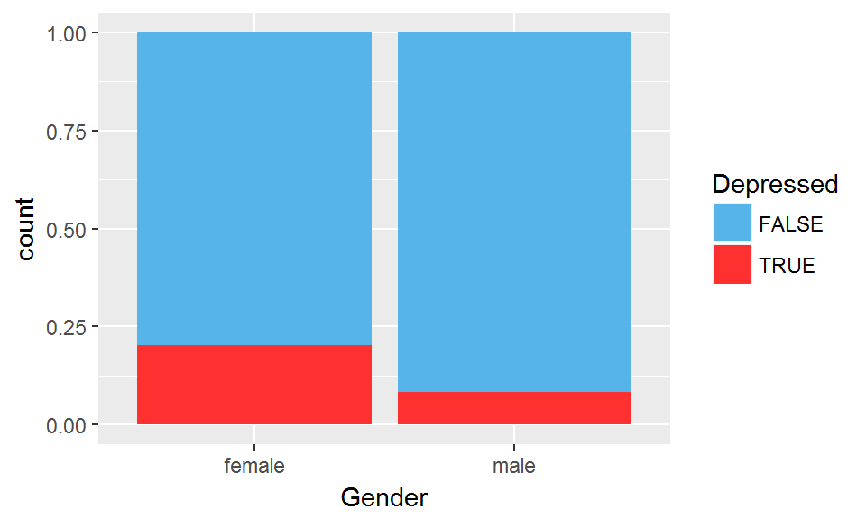

```r
genD <- ggplot(ym, aes(x = Gender, fill = Depressed)) + geom_bar(position="fill") + scale_fill_manual(values=Palette)
genD
```

There are some patterns visible. The gender difference regarding depression is usually found in real studies as well.

Let’s check out music and movie preference correlations with `Depression`.

```r
cor(ym[9:27], ym[4]) %>% round(digits = 2)
```

```
##                Depression
## Music                0.02
## Slow_vs_Fast        -0.17
## Dance               -0.12
## Folk                 0.01
## Country             -0.01
## Classical            0.11
## Musical              0.08
## Pop                  0.02
## Rock                 0.10
## Metal_Hardrock      -0.01
## Punk                 0.02
## Hiphop_Rap          -0.17
## Reggae_Ska          -0.08
## Swing_Jazz           0.05
## Rocknroll            0.04
## Alternative          0.08
## Latino              -0.03
## Techno_Trance       -0.08
## Opera                0.02
```

```r
cor(ym[28:39], ym[4]) %>% round(digits = 2)
```

```
##             Depression
## Movies            0.00
## Horror           -0.03
## Thriller         -0.02
## Comedy           -0.04
## Romantic          0.16
## Sci.fi           -0.02
## War              -0.10
## Tales             0.08
## Animated          0.08
## Documentary      -0.03
## Western          -0.13
## Action           -0.21
```

Depressed people seem to prefer slow, classical and rock music, and dislike rap and dance. As a side note the boys’ `Musical` variable has opposite correlation with `Depression` to girls’ one.

In the movie section highest positive correlation is with `Romantic` and highest negative correlation with `Action`.

Some barcharts of the most interesting variables:

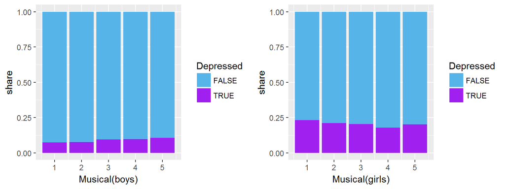

```r
musicalboys <- ggplot(filter(ym, Gender == "male"), aes(x = Musical, fill = Depressed)) + geom_bar(position="fill") + scale_fill_manual(values=Palette4) + xlab("Musical(boys)")  + ylab("share")
musicalgirls <- ggplot(filter(ym, Gender == "female"), aes(x = Musical, fill = Depressed)) + geom_bar(position="fill") + scale_fill_manual(values=Palette4) + xlab("Musical(girls)") + ylab("share")
grid.arrange(musicalboys, musicalgirls, ncol=2)
```

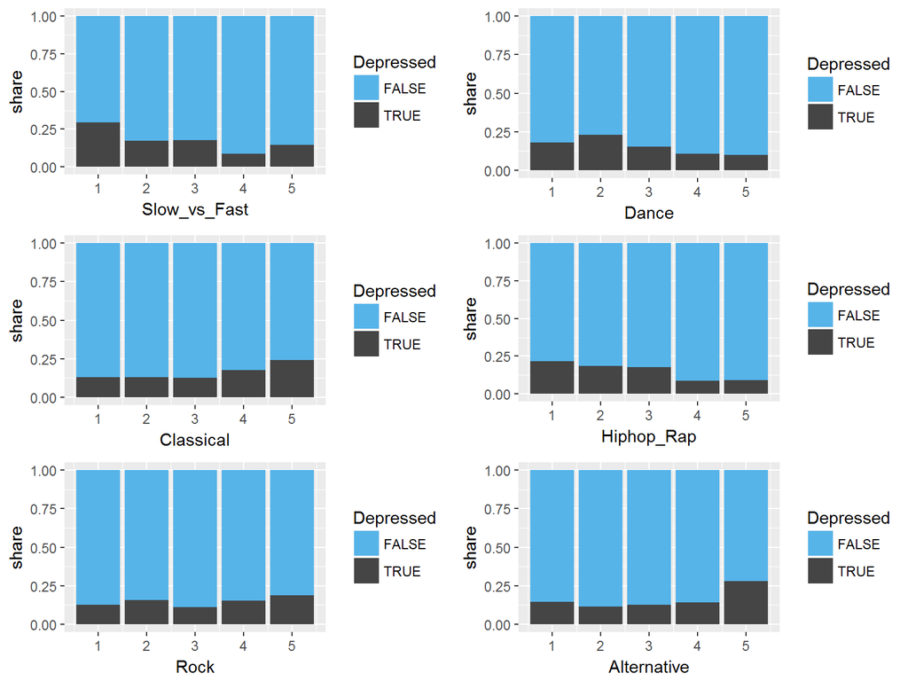

```r
slowD <- ggplot(ym, aes(x = Slow_vs_Fast, fill = Depressed)) + geom_bar(position="fill") + scale_fill_manual(values=Palette2) + ylab("share")
danceD <- ggplot(ym, aes(x = Dance, fill = Depressed)) + geom_bar(position="fill") + scale_fill_manual(values=Palette2) + ylab("share")
classicalD <- ggplot(ym, aes(x = Classical, fill = Depressed)) + geom_bar(position="fill") + scale_fill_manual(values=Palette2)+ ylab("share")
rapD <- ggplot(ym, aes(x = Hiphop_Rap, fill = Depressed)) + geom_bar(position="fill") + scale_fill_manual(values=Palette2) + ylab("share")
rockD <- ggplot(ym, aes(x = Rock, fill = Depressed)) + geom_bar(position="fill") + scale_fill_manual(values=Palette2) + ylab("share")
altD <- ggplot(ym, aes(x = Alternative, fill = Depressed)) + geom_bar(position="fill") + scale_fill_manual(values=Palette2) + ylab("share")
grid.arrange(slowD, danceD, classicalD, rapD, rockD, altD, ncol=2)
```

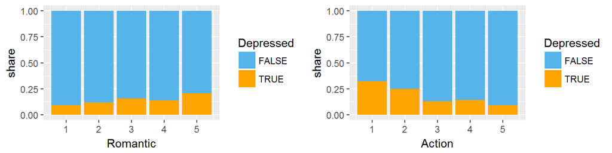

```r
romD <- ggplot(ym, aes(x = Romantic, fill = Depressed)) + geom_bar(position="fill") + scale_fill_manual(values=Palette3) + ylab("share")
actD <- ggplot(ym, aes(x = Action, fill = Depressed)) + geom_bar(position="fill") + scale_fill_manual(values=Palette3) + ylab("share")
grid.arrange(romD, actD, ncol=2)
```

Could there be statistical significance to any explanatory connection in the data regarding the `Depression` variable?

## Modelling

#### Simple and multiple linear modelling

First let’s try a linear model to explain `Depression` with `Sports`, `Healthy_eating`, `BMI`.

```r
m <- lm(Depression ~ Sports + Healthy_eating + BMI , data = ym)
summary(m)
```

```
##
## Call:
## lm(formula = Depression ~ Sports + Healthy_eating + BMI, data = ym)
##
## Residuals:
##      Min       1Q   Median       3Q      Max
## -1.75843 -0.32943 -0.01905  0.32752  1.82148
##
## Coefficients:
##                 Estimate Std. Error t value Pr(>|t|)
## (Intercept)     3.506365   0.104758  33.471  < 2e-16 ***
## Sports         -0.110993   0.016394  -6.770 2.43e-11 ***
## Healthy_eating -0.058922   0.019460  -3.028  0.00254 **
## BMI            -0.006323   0.003435  -1.841  0.06598 .
## ---
## Signif. codes:  0 '***' 0.001 '**' 0.01 '*' 0.05 '.' 0.1 ' ' 1
##
## Residual standard error: 0.5158 on 828 degrees of freedom
## Multiple R-squared:  0.07625,    Adjusted R-squared:  0.0729
## F-statistic: 22.78 on 3 and 828 DF,  p-value: 3.536e-14
```

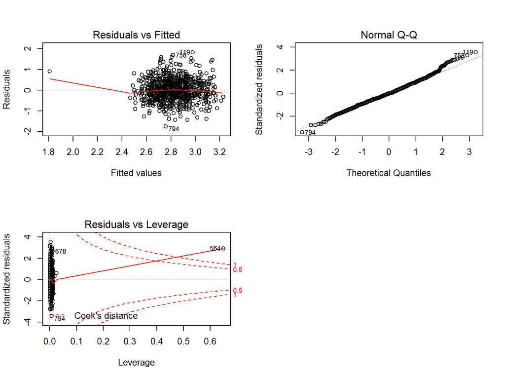

```r
par(mfrow = c(2,2))
plot(m, which = c(1,2,5))
```

`BMI`is not statistically significant and seems to cause problems as there are some high leverage outliers. So I think the model will work better if I drop the variable altogether.

```r
m2 <- lm(Depression ~ Sports + Healthy_eating , data = ym)
summary(m2)
```

```
##
## Call:
## lm(formula = Depression ~ Sports + Healthy_eating, data = ym)
##
## Residuals:
##      Min       1Q   Median       3Q      Max
## -1.74120 -0.33197 -0.02797  0.32649  1.82859
##
## Coefficients:
##                Estimate Std. Error t value Pr(>|t|)
## (Intercept)     3.37329    0.07593  44.426  < 2e-16 ***
## Sports         -0.11312    0.01638  -6.907 9.83e-12 ***
## Healthy_eating -0.05855    0.01949  -3.004  0.00274 **
## ---
## Signif. codes:  0 '***' 0.001 '**' 0.01 '*' 0.05 '.' 0.1 ' ' 1
##
## Residual standard error: 0.5166 on 829 degrees of freedom
## Multiple R-squared:  0.07247,    Adjusted R-squared:  0.07023
## F-statistic: 32.38 on 2 and 829 DF,  p-value: 2.87e-14
```

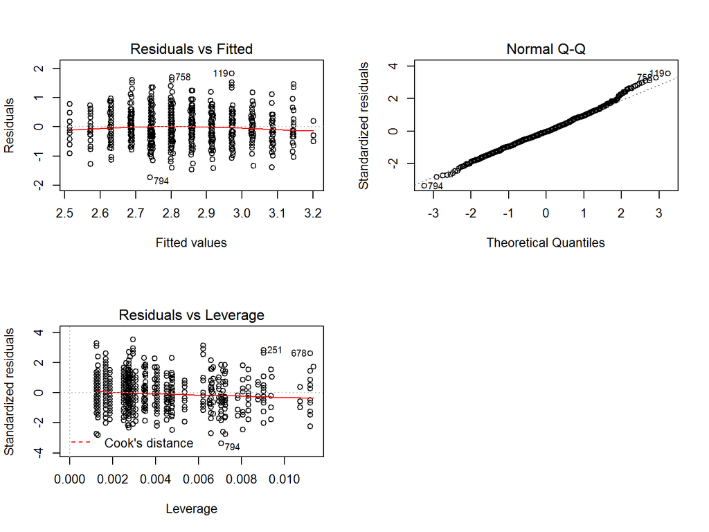

```r
par(mfrow = c(2,2))
plot(m2, which = c(1,2,5))
```

Now there are no powerful outliers so the model looks good.

Let’s create another model with music preference explanatory variables.

```r
mm <- lm(Depression ~ Slow_vs_Fast + Hiphop_Rap + Classical, data = ym)
summary(mm)
```

```
##
## Call:
## lm(formula = Depression ~ Slow_vs_Fast + Hiphop_Rap + Classical,
##     data = ym)
##
## Residuals:
##      Min       1Q   Median       3Q      Max
## -1.81572 -0.34620 -0.03087  0.31160  2.00982
##
## Coefficients:
##              Estimate Std. Error t value Pr(>|t|)
## (Intercept)   3.22587    0.10275  31.394  < 2e-16 ***
## Slow_vs_Fast -0.09825    0.02287  -4.296 1.94e-05 ***
## Hiphop_Rap   -0.05576    0.01354  -4.119 4.18e-05 ***
## Classical     0.02737    0.01474   1.857   0.0637 .
## ---
## Signif. codes:  0 '***' 0.001 '**' 0.01 '*' 0.05 '.' 0.1 ' ' 1
##
## Residual standard error: 0.5213 on 828 degrees of freedom
## Multiple R-squared:  0.05649,    Adjusted R-squared:  0.05307
## F-statistic: 16.52 on 3 and 828 DF,  p-value: 1.954e-10
```

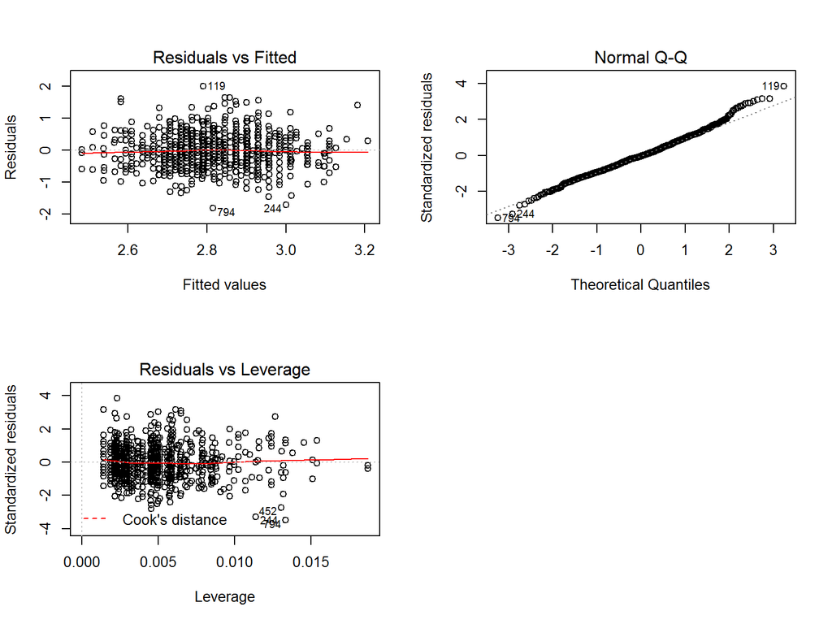

```r
par(mfrow = c(2,2))
plot(mm, which = c(1,2,5))
```

The model diagnostics imply that the model assumptions are OK.

#### Logistic linear modelling

With logistic linear modelling it is possible to classify observations into groups. I’m interested in the logical `Depressed` variable I created.

```r
m3<- glm(Depressed ~ Action , data = ym, family = "binomial")
summary(m3)
```

```
##
## Call:
## glm(formula = Depressed ~ Action, family = "binomial", data = ym)
##
## Deviance Residuals:
##     Min       1Q   Median       3Q      Max
## -0.8505  -0.6143  -0.5176  -0.4344   2.1943
##
## Coefficients:
##             Estimate Std. Error z value Pr(>|z|)
## (Intercept) -0.46012    0.26106  -1.762    0.078 .
## Action      -0.37062    0.07709  -4.808 1.53e-06 ***
## ---
## Signif. codes:  0 '***' 0.001 '**' 0.01 '*' 0.05 '.' 0.1 ' ' 1
##
## (Dispersion parameter for binomial family taken to be 1)
##
##     Null deviance: 717.79  on 831  degrees of freedom
## Residual deviance: 694.36  on 830  degrees of freedom
## AIC: 698.36
##
## Number of Fisher Scoring iterations: 4
```

```r
OR <- coef(m3) %>% exp
CI <- exp(confint(m3))
cbind(OR, CI)
```

```
##                    OR     2.5 %    97.5 %
## (Intercept) 0.6312084 0.3755346 1.0468260
## Action      0.6903086 0.5927528 0.8022764
```

```r
probabilities <- predict(m3, type ="response")
ym <- mutate(ym, probability = probabilities)
ym <- mutate(ym, prediction = probability > 0.2)
table(Depressed = ym$Depressed, prediction = ym$prediction)
```

```
##          prediction
## Depressed FALSE TRUE
##     FALSE   566  137
##     TRUE     78   51
```

Predicting depressive tendencies based on if a person likes action movies is not the most effective way maybe but the `Action` movies variable has some effect on the `Depression`variable.

## Conclusions

In conclusion the variable `Depression` I created had some intuitive and meaningful connections with the rest of the data, even though low in explaining power, which is to be expected. Anyway there were music and movie preferences that correlate with depressed and anxious thinking. Especially action movies were disliked by youngsters with higher depression tendencies. Also sports as a hobby predicts lower chance of depression.